# Objective

Given a Bank customer, build a neural network based classifier that can determine whether they will leave or not in the next 6 months.

## Import Libraries

```python
import warnings
warnings.filterwarnings('ignore')
```

```python
%matplotlib inline
import numpy as np
import pandas as pd
import matplotlib.pyplot as plt
import seaborn as sns
from sklearn.preprocessing import StandardScaler
from sklearn.model_selection import train_test_split
import tensorflow as tf
from sklearn import preprocessing
from tensorflow.keras.models import Sequential
from tensorflow.keras.layers import Dense, Dropout, BatchNormalization
from sklearn.metrics import accuracy_score, confusion_matrix
from tensorflow.keras import optimizers
```

## Import Dataset

```python
# Read the file
df=pd.read_csv('bank.csv')
```

## EDA

```python
df.info()       # Info about dataframe, columns, data types, Null values
```

```
<class 'pandas.core.frame.DataFrame'>
RangeIndex: 10000 entries, 0 to 9999
Data columns (total 14 columns):
 #   Column           Non-Null Count  Dtype
---  ------           --------------  -----
 0   RowNumber        10000 non-null  int64
 1   CustomerId       10000 non-null  int64
 2   Surname          10000 non-null  object
 3   CreditScore      10000 non-null  int64
 4   Geography        10000 non-null  object
 5   Gender           10000 non-null  object
 6   Age              10000 non-null  int64
 7   Tenure           10000 non-null  int64
 8   Balance          10000 non-null  float64
 9   NumOfProducts    10000 non-null  int64
 10  HasCrCard        10000 non-null  int64
 11  IsActiveMember   10000 non-null  int64
 12  EstimatedSalary  10000 non-null  float64
 13  Exited           10000 non-null  int64
dtypes: float64(2), int64(9), object(3)
memory usage: 1.1+ MB
```

```python
df.head()                                          # First five rows
```

|  | RowNumber | CustomerId | Surname | CreditScore | Geography | Gender | Age | Tenure | Balance | NumOfProducts | HasCrCard | IsActiveMember | EstimatedSalary | Exited |
| --- | --- | --- | --- | --- | --- | --- | --- | --- | --- | --- | --- | --- | --- | --- |
| 0 | 1 | 15634602 | Hargrave | 619 | France | Female | 42 | 2 | 0.00 | 1 | 1 | 1 | 101348.88 | 1 |
| 1 | 2 | 15647311 | Hill | 608 | Spain | Female | 41 | 1 | 83807.86 | 1 | 0 | 1 | 112542.58 | 0 |
| 2 | 3 | 15619304 | Onio | 502 | France | Female | 42 | 8 | 159660.80 | 3 | 1 | 0 | 113931.57 | 1 |
| 3 | 4 | 15701354 | Boni | 699 | France | Female | 39 | 1 | 0.00 | 2 | 0 | 0 | 93826.63 | 0 |
| 4 | 5 | 15737888 | Mitchell | 850 | Spain | Female | 43 | 2 | 125510.82 | 1 | 1 | 1 | 79084.10 | 0 |

```python
df.tail()                                          # Last five rows
```

|  | RowNumber | CustomerId | Surname | CreditScore | Geography | Gender | Age | Tenure | Balance | NumOfProducts | HasCrCard | IsActiveMember | EstimatedSalary | Exited |
| --- | --- | --- | --- | --- | --- | --- | --- | --- | --- | --- | --- | --- | --- | --- |
| 9995 | 9996 | 15606229 | Obijiaku | 771 | France | Male | 39 | 5 | 0.00 | 2 | 1 | 0 | 96270.64 | 0 |
| 9996 | 9997 | 15569892 | Johnstone | 516 | France | Male | 35 | 10 | 57369.61 | 1 | 1 | 1 | 101699.77 | 0 |
| 9997 | 9998 | 15584532 | Liu | 709 | France | Female | 36 | 7 | 0.00 | 1 | 0 | 1 | 42085.58 | 1 |
| 9998 | 9999 | 15682355 | Sabbatini | 772 | Germany | Male | 42 | 3 | 75075.31 | 2 | 1 | 0 | 92888.52 | 1 |
| 9999 | 10000 | 15628319 | Walker | 792 | France | Female | 28 | 4 | 130142.79 | 1 | 1 | 0 | 38190.78 | 0 |

```python
print('-----Number of Nulls-----')
df.isnull().sum()                                  # Check Null values
```

```
-----Number of Nulls-----
```

```
RowNumber          0
CustomerId         0
Surname            0
CreditScore        0
Geography          0
Gender             0
Age                0
Tenure             0
Balance            0
NumOfProducts      0
HasCrCard          0
IsActiveMember     0
EstimatedSalary    0
Exited             0
dtype: int64
```

```python
print('-----Number of unique values-----')
df.nunique()                                       # Number of unique values in each column
```

```
-----Number of unique values-----
```

```
RowNumber          10000
CustomerId         10000
Surname             2932
CreditScore          460
Geography              3
Gender                 2
Age                   70
Tenure                11
Balance             6382
NumOfProducts          4
HasCrCard              2
IsActiveMember         2
EstimatedSalary     9999
Exited                 2
dtype: int64
```

```python
print('Shape of the dataframe is:',df.shape)       # Shape of data frame
df.describe().transpose()                          # Statistical summary
```

```
Shape of the dataframe is: (10000, 14)
```

|  | count | mean | std | min | 25% | 50% | 75% | max |
| --- | --- | --- | --- | --- | --- | --- | --- | --- |
| RowNumber | 10000.0 | 5.000500e+03 | 2886.895680 | 1.00 | 2500.75 | 5.000500e+03 | 7.500250e+03 | 10000.00 |
| CustomerId | 10000.0 | 1.569094e+07 | 71936.186123 | 15565701.00 | 15628528.25 | 1.569074e+07 | 1.575323e+07 | 15815690.00 |
| CreditScore | 10000.0 | 6.505288e+02 | 96.653299 | 350.00 | 584.00 | 6.520000e+02 | 7.180000e+02 | 850.00 |
| Age | 10000.0 | 3.892180e+01 | 10.487806 | 18.00 | 32.00 | 3.700000e+01 | 4.400000e+01 | 92.00 |
| Tenure | 10000.0 | 5.012800e+00 | 2.892174 | 0.00 | 3.00 | 5.000000e+00 | 7.000000e+00 | 10.00 |
| Balance | 10000.0 | 7.648589e+04 | 62397.405202 | 0.00 | 0.00 | 9.719854e+04 | 1.276442e+05 | 250898.09 |
| NumOfProducts | 10000.0 | 1.530200e+00 | 0.581654 | 1.00 | 1.00 | 1.000000e+00 | 2.000000e+00 | 4.00 |
| HasCrCard | 10000.0 | 7.055000e-01 | 0.455840 | 0.00 | 0.00 | 1.000000e+00 | 1.000000e+00 | 1.00 |
| IsActiveMember | 10000.0 | 5.151000e-01 | 0.499797 | 0.00 | 0.00 | 1.000000e+00 | 1.000000e+00 | 1.00 |
| EstimatedSalary | 10000.0 | 1.000902e+05 | 57510.492818 | 11.58 | 51002.11 | 1.001939e+05 | 1.493882e+05 | 199992.48 |
| Exited | 10000.0 | 2.037000e-01 | 0.402769 | 0.00 | 0.00 | 0.000000e+00 | 0.000000e+00 | 1.00 |

#### Remove RowNumber, CustomerId and Surname since they are redundant

```python
df.drop(['RowNumber','CustomerId','Surname'], axis=1, inplace=True)
df_columns_num = ['CreditScore','Age','Tenure','Balance','EstimatedSalary']
```

##### Plots to visualize data

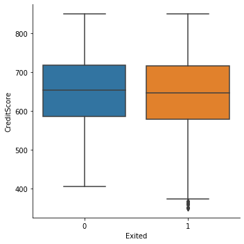

```python
sns.catplot(x='Exited', y='CreditScore', kind='box', data=df);
```

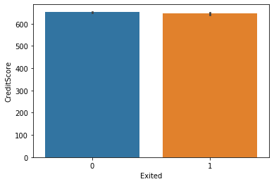

```python
sns.barplot(x='Exited', y='CreditScore', data=df)
plt.show();
```

As we can see from above plots, credit score doesn'y have an impact on target variable that much. Although customers with low credit scores (less than 400) have more chances to churn.

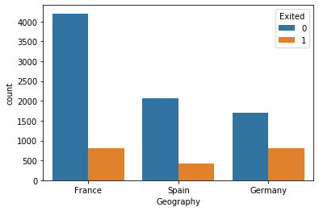

```python
sns.countplot(x='Geography', hue='Exited', data = df);
```

We see a high number of customer churn rate in Germany

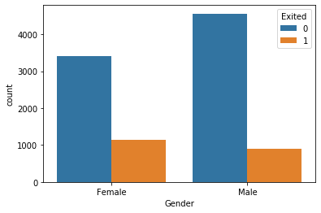

```python
sns.countplot(x='Gender', hue='Exited', data = df);
```

We see females have a higher churn rate

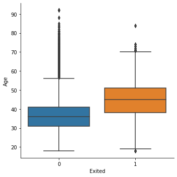

```python
sns.catplot(x='Exited', y='Age', kind='box', data=df);
```

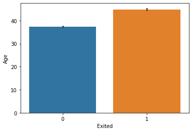

```python
sns.barplot(x='Exited', y='Age', data=df)
plt.show();
```

Customers above the age of 40 have a higher churn rate

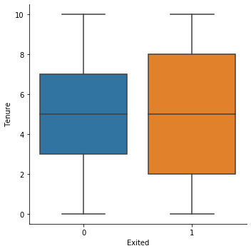

```python
sns.catplot(x='Exited', y='Tenure', kind='box', data=df);
```

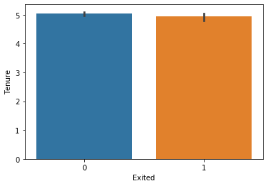

```python
sns.barplot(x='Exited', y='Tenure', data=df)
plt.show();
```

Tenure doesn't seem to have that of an impact on customer churn rate

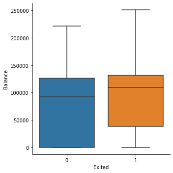

```python
sns.catplot(x='Exited', y='Balance', kind='box', data=df);
```

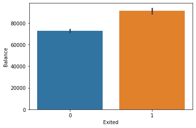

```python
sns.barplot(x='Exited', y='Balance', data=df);
```

Customers with high balance have higher churn rate

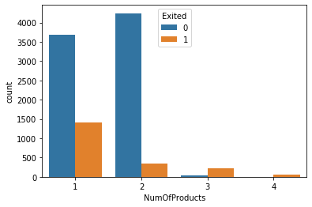

```python
sns.countplot(x='NumOfProducts', hue='Exited', data = df);
```

Customers with 3 or 4 products have higher churn rate

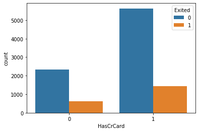

```python
sns.countplot(x='HasCrCard', hue='Exited', data = df);
```

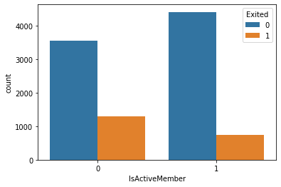

```python
sns.countplot(x='IsActiveMember', hue='Exited', data = df);
```

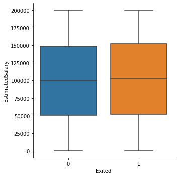

```python
sns.catplot(x='Exited', y='EstimatedSalary', kind='box', data=df);
```

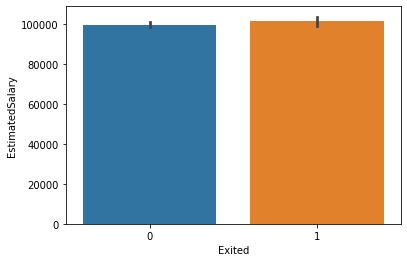

```python
sns.barplot(x='Exited', y='EstimatedSalary', data=df);
```

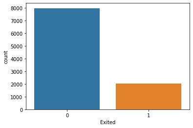

```python
sns.countplot(x='Exited', data = df);
```

```python
df['Exited'].value_counts(normalize=True) # value counts %age
```

```
0    0.7963
1    0.2037
Name: Exited, dtype: float64
```

We see from above chart there is class imbalance.

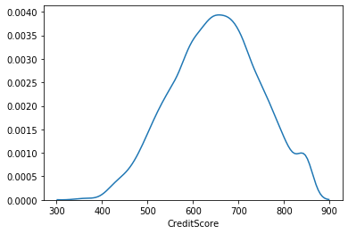

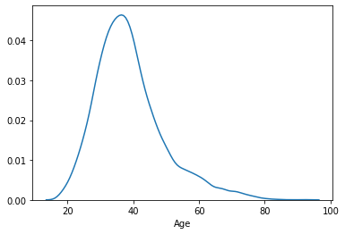

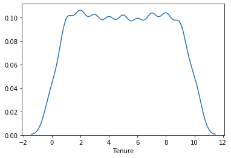

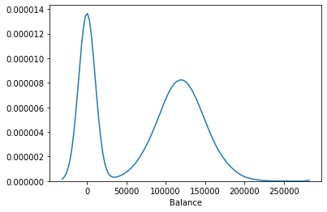

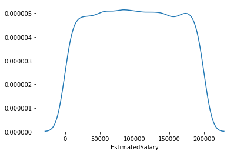

```python
for i in df_columns_num:
    sns.distplot(df[i],hist=False,)
    plt.show()
```

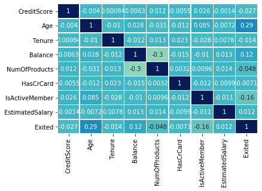

```python
sns.heatmap(df.corr(),
            annot=True,
            linewidths=.5,
            center=0,
            cbar=False,
            cmap="YlGnBu")

plt.show();
```

- From the map above, we see that there is some +ve corelation between age and balance as compared to others with target variable.
- We see that there is -ve corelation between Is Active member and target variable when compared with other variables.

### Separate out independent and dependent variables

```python
X = df.iloc[:,:10]
Y = df.iloc[:,10]
```

#### Get dummies for Categorical variables

```python
New_Geography=pd.get_dummies(X['Geography'])
New_Gender=pd.get_dummies(X['Gender'])
```

```python
X=pd.concat([X,New_Geography,New_Gender],axis=1)
X=X.drop(['Geography','Gender'],axis=1)
```

#### Normalize the data

```python
X=preprocessing.normalize(X)
```

### Divide into train and test

```python
x_train, x_test, y_train, y_test = train_test_split(X, Y, test_size=0.30,random_state=1)   # Split data in 70:30 ratio
```

```python
x_train.shape
```

```
(7000, 13)
```

```python
x_test.shape
```

```
(3000, 13)
```

```python
y_train.shape
```

```
(7000,)
```

```python
y_test.shape
```

```
(3000,)
```

#### Use Standard Scaler to scale the data

```python
sc = StandardScaler()
x_train = sc.fit_transform(x_train)
x_test = sc.transform(x_test)
```

### Activation function as 'elu'

```python
model1 = Sequential()
# Add the first hidden layer
model1.add(Dense(64, input_shape = (13,), activation = 'elu'))
# Adding the second hidden layer
model1.add(Dense(32, activation = 'elu'))
# Adding the output layer
model1.add(Dense(1, activation = 'sigmoid'))
```

###### Learning rate as 0.001

```python
sgd = optimizers.Adam(lr = 0.001)
```

##### Loss function binary cross entropy

```python
model1.compile(optimizer = sgd, loss = 'binary_crossentropy', metrics=['accuracy'])
```

```python
model1.summary()
```

```
Model: "sequential"
_________________________________________________________________
Layer (type)                 Output Shape              Param #
=================================================================
dense (Dense)                (None, 64)                896
_________________________________________________________________
dense_1 (Dense)              (None, 32)                2080
_________________________________________________________________
dense_2 (Dense)              (None, 1)                 33
=================================================================
Total params: 3,009
Trainable params: 3,009
Non-trainable params: 0
_________________________________________________________________
```

```python
model1.fit(x_train, y_train.values, batch_size = 50, epochs = 100, verbose = 1)
```

```
Train on 7000 samples
```

```
<tensorflow.python.keras.callbacks.History at 0x136b1fce3c8>
```

```python
results = model1.evaluate(x_test, y_test.values)
```

```python
# Predict using the model
y_pred = model1.predict(x_test)
# with a threshold of 50%
y_pred = (y_pred > 0.5)
```

#### Print Accuracy and Confusion Matrix

```python
print(model1.metrics_names)
print(results)
confusion_matrix(y_test.values, y_pred)
```

```
['loss', 'accuracy']
[0.4248593197663625, 0.82733333]
```

```
array([[2336,   37],
       [ 481,  146]], dtype=int64)
```

#### Let's try to change the learning rate to 0.01 keeping rest of parameters as same

```python
model2 = Sequential()
# Add the first hidden layer
model2.add(Dense(64, input_shape = (13,), activation = 'elu'))
# Adding the second hidden layer
model2.add(Dense(32, activation = 'elu'))
# Adding the output layer
model2.add(Dense(1, activation = 'sigmoid'))
sgd = optimizers.Adam(lr = 0.01)
```

```python
model2.compile(optimizer = sgd, loss = 'binary_crossentropy', metrics=['accuracy'])
```

```python
model2.summary()
```

```
Model: "sequential_1"
_________________________________________________________________
Layer (type)                 Output Shape              Param #
=================================================================
dense_3 (Dense)              (None, 64)                896
_________________________________________________________________
dense_4 (Dense)              (None, 32)                2080
_________________________________________________________________
dense_5 (Dense)              (None, 1)                 33
=================================================================
Total params: 3,009
Trainable params: 3,009
Non-trainable params: 0
_________________________________________________________________
```

```python
model2.fit(x_train, y_train.values, batch_size = 50, epochs = 100, verbose = 1)
```

```
Train on 7000 samples
```

```
<tensorflow.python.keras.callbacks.History at 0x136b1903cc8>
```

```python
results = model2.evaluate(x_test, y_test.values)
```

```python
# Predict using the model
y_pred = model2.predict(x_test)
# with a threshold of 50%
y_pred = (y_pred > 0.5)
```

#### Print Accuracy and Confusion Matrix

```python
print(model2.metrics_names)
print(results)
confusion_matrix(y_test.values, y_pred)
```

```
['loss', 'accuracy']
[0.3629866991043091, 0.86466664]
```

```
array([[2257,  116],
       [ 290,  337]], dtype=int64)
```

### Let's use activation function as relu

```python
model3=Sequential()
# Add the first hidden layer
model3.add(Dense(64, input_shape = (13,), activation = 'relu'))
# Adding the second hidden layer
model3.add(Dense(32, activation = 'relu'))
# Adding the output layer
model3.add(Dense(1, activation = 'sigmoid'))
```

##### Learning rate as 0.001

```python
sgd = optimizers.Adam(lr = 0.001)
```

```python
model3.compile(optimizer = sgd, loss = 'binary_crossentropy', metrics=['accuracy'])
```

```python
model3.fit(x_train, y_train.values, batch_size = 50, epochs = 100, verbose = 1)
```

```
Train on 7000 samples
```

```
<tensorflow.python.keras.callbacks.History at 0x136b3e1eb08>
```

```python
# Predict using the model
y_pred = model3.predict(x_test)
# with a threshold of 50%
y_pred = (y_pred > 0.5)
```

```python
results = model3.evaluate(x_test, y_test.values)
```

#### Print Accuracy and Confusion Matrix

```python
print(model3.metrics_names)
print(results)
confusion_matrix(y_test.values, y_pred)
```

```
['loss', 'accuracy']
[0.4089916586081187, 0.83533335]
```

```
array([[2298,   75],
       [ 419,  208]], dtype=int64)
```

##### Let's change learning rate as 0.01

```python
model4=Sequential()
# Add the first hidden layer
model4.add(Dense(64, input_shape = (13,), activation = 'relu'))
# Adding the second hidden layer
model4.add(Dense(32, activation = 'relu'))
# Adding the output layer
model4.add(Dense(1, activation = 'sigmoid'))
```

```python
sgd = optimizers.Adam(lr = 0.01)
```

```python
model4.compile(optimizer = sgd, loss = 'binary_crossentropy', metrics=['accuracy'])
```

```python
model4.fit(x_train, y_train.values, batch_size = 50, epochs = 100, verbose = 1)
```

```
Train on 7000 samples
```

```
<tensorflow.python.keras.callbacks.History at 0x136b4697208>
```

```python
results = model4.evaluate(x_test, y_test.values)
```

```python
# Predict using the model
y_pred = model4.predict(x_test)
# with a threshold of 50%
y_pred = (y_pred > 0.5)
```

#### Print Accuracy and Confusion Matrix

```python
print(model4.metrics_names)
print(results)
confusion_matrix(y_test.values, y_pred)
```

```
['loss', 'accuracy']
[0.4122247603734334, 0.85433334]
```

```
array([[2312,   61],
       [ 376,  251]], dtype=int64)
```

#### Different activation functions for hidden layers

```python
model5=Sequential()
# Add the first hidden layer
model5.add(Dense(64, input_shape = (13,), activation = 'elu'))
# Adding the second hidden layer
model5.add(Dense(32, activation = 'relu'))
# Adding the output layer
model5.add(Dense(1, activation = 'sigmoid'))
```

##### Learning rate as 0.001

```python
sgd = optimizers.Adam(lr = 0.001)
```

```python
model5.compile(optimizer = sgd, loss = 'binary_crossentropy', metrics=['accuracy'])
```

```python
model5.fit(x_train, y_train.values, batch_size = 50, epochs = 100, verbose = 1)
```

```
Train on 7000 samples
```

```
<tensorflow.python.keras.callbacks.History at 0x136b5ee3788>
```

```python
results = model5.evaluate(x_test, y_test.values)
```

```python
# Predict using the model
y_pred = model5.predict(x_test)
# with a threshold of 50%
y_pred = (y_pred > 0.5)
```

#### Print Accuracy and Confusion Matrix

```python
print(model5.metrics_names)
print(results)
confusion_matrix(y_test.values, y_pred)
```

```
['loss', 'accuracy']
[0.37004772051175433, 0.85333335]
```

```
array([[2277,   96],
       [ 344,  283]], dtype=int64)
```

##### Change Learning rate to 0.01

```python
model6=Sequential()
# Add the first hidden layer
model6.add(Dense(64, input_shape = (13,), activation = 'elu'))
# Adding the second hidden layer
model6.add(Dense(32, activation = 'relu'))
# Adding the output layer
model6.add(Dense(1, activation = 'sigmoid'))
```

```python
sgd = optimizers.Adam(lr = 0.01)
```

```python
model6.compile(optimizer = sgd, loss = 'binary_crossentropy', metrics=['accuracy'])
```

```python
model6.fit(x_train, y_train.values, batch_size = 50, epochs = 100, verbose = 1)
```

```
Train on 7000 samples
```

```
<tensorflow.python.keras.callbacks.History at 0x136b673e188>
```

```python
results = model6.evaluate(x_test, y_test.values)
```

```python
# Predict using the model
y_pred = model6.predict(x_test)
# with a threshold of 50%
y_pred = (y_pred > 0.5)
```

#### Print Accuracy and Confusion Matrix

```python
print(model6.metrics_names)
print(results)
confusion_matrix(y_test.values, y_pred)
```

```
['loss', 'accuracy']
[0.3559159570535024, 0.8606667]
```

```
array([[2273,  100],
       [ 318,  309]], dtype=int64)
```

## Conclusion

As we see above even after changing learning rate and/or activation functions we get different accuracies and loss.

- Please note these can/would change on each run.